# BRUV data summary 2019

Jessica Madden

November 30, 2020

A total of **39 species** belonging to **17 families** were recorded from BRUV deployments at all of the locations combined. This summary includes MaxN data recorded to species (with the exception of the category ‘unknown silversides’). There are a number of point tags that are to genus, family, or unknown that are not included here, though these tags that are excluded should not greatly affect the species richness or MaxN data represented here.

### Species Richness

**Table 1.** Total species richness at each site. Species richness represents number of unique species (Actinopterygii, Elasmobranchii) observed in all BRUV videos at each site (n = 9). For all MPA/Reference pairs except the San Diego site, the MPA site had greater species richness.

| Site | Type | Species richness |
| --- | --- | --- |
| Percos | MPA | 12 |
| Refugio | Reference | 11 |
| South Campus | MPA | 19 |
| Haskells | Reference | 12 |
| Dume Cove | MPA | 18 |
| Leo Carrillo | Reference | 12 |
| Sleepy Hollow | MPA | 22 |
| Strands | Reference | 14 |
| Scripps | MPA | 12 |
| San Elijo | Reference | 15 |

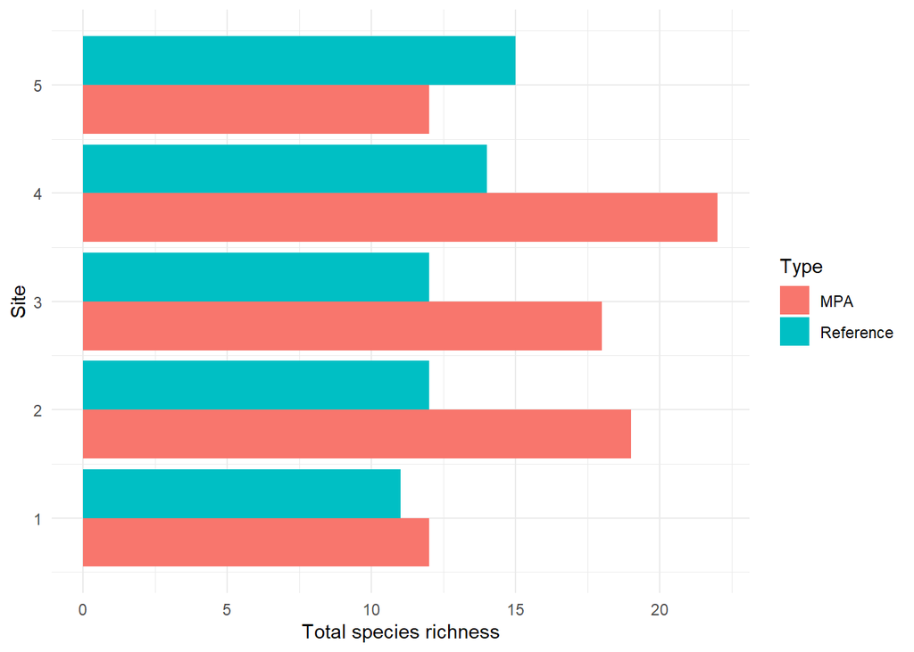

**Figure 1.** Total species richness at each site. Species richness represents number of unique species (Actinopterygii, Elasmobranchii) observed in all BRUV videos at each site (n = 9). Sites are ordered MPA first and reference second, with pairs in order of decreasing latitude.

### Mean species richness: MPA vs. Reference comparison

Average number of unique individuals of either subclass Actinopterygii or Elasmobranchii per bruv deployment in MPAs vs. Reference sites

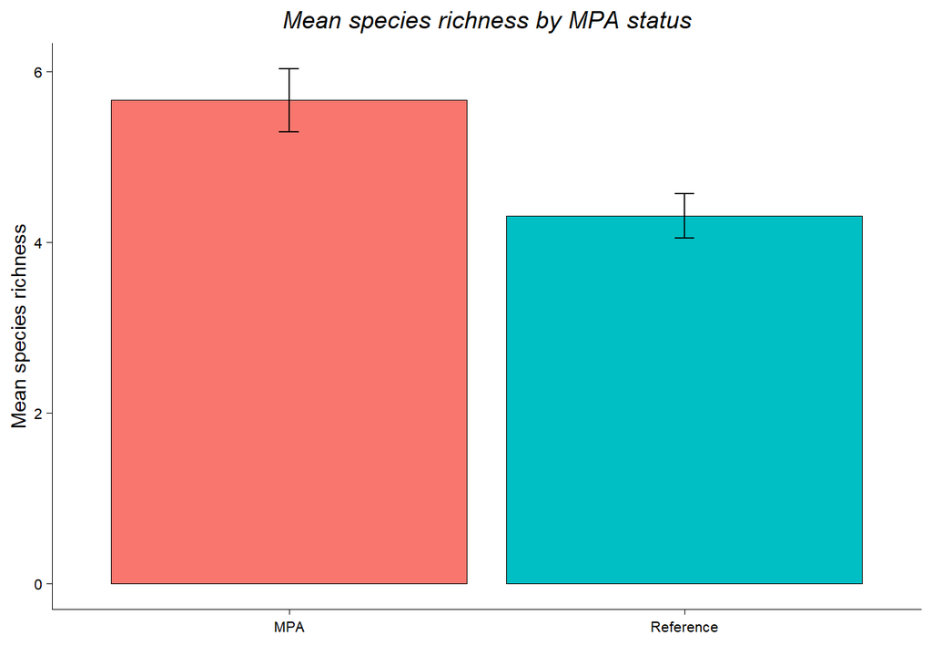

**Figure.** Mean species richness with MPA and reference sites, averaged from each BRUV deployment.

### Mean Total Species Richness

**Table 2.** Summary statistics of species richness from BRUV deployments at ten sampling locations. Mean species richness represents the number of unique species (Actinopterygii, Elasmobranchii) observed in each deployment averaged across all deployments for each site.

| Site | Type | Mean species richness | Standard Error | Min | Max | Sample size |
| --- | --- | --- | --- | --- | --- | --- |
| Percos | MPA | 3.78 | 0.52 | 2 | 6 | 9 |
| Refugio | Reference | 3.89 | 0.48 | 2 | 7 | 9 |
| South Campus | MPA | 7.22 | 0.94 | 3 | 11 | 9 |
| Haskells | Reference | 3.67 | 0.37 | 2 | 5 | 9 |
| Dume Cove | MPA | 6.56 | 0.44 | 5 | 9 | 9 |
| Leo Carrillo | Reference | 4.78 | 0.52 | 2 | 7 | 9 |
| Sleepy Hollow | MPA | 5.67 | 1.07 | 1 | 13 | 9 |
| Strands | Reference | 4.67 | 0.88 | 1 | 8 | 9 |
| Scripps | MPA | 5.11 | 0.61 | 2 | 8 | 9 |
| San Elijo | Reference | 4.56 | 0.60 | 2 | 8 | 9 |

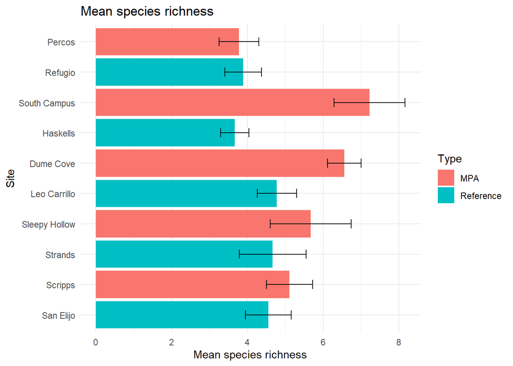

**Figure 2.** Mean species richness at each site. Mean species richness represents the number of unique species (Actinopterygii, Elasmobranchii) observed in each deployment averaged across all deployments for each site (n = 9). Error bars indicate standard error. Sites are ordered MPA first and reference second, with pairs in order of decreasing latitude.

### Mean species richness: Actinopterygii

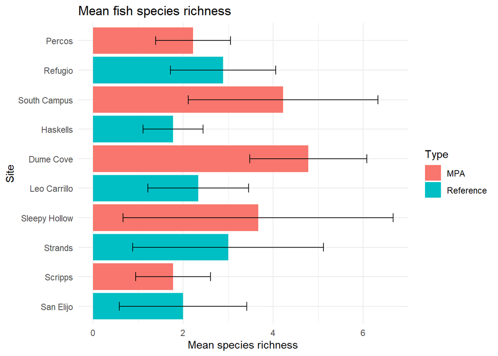

### Mean species richness: Elasmobranchii

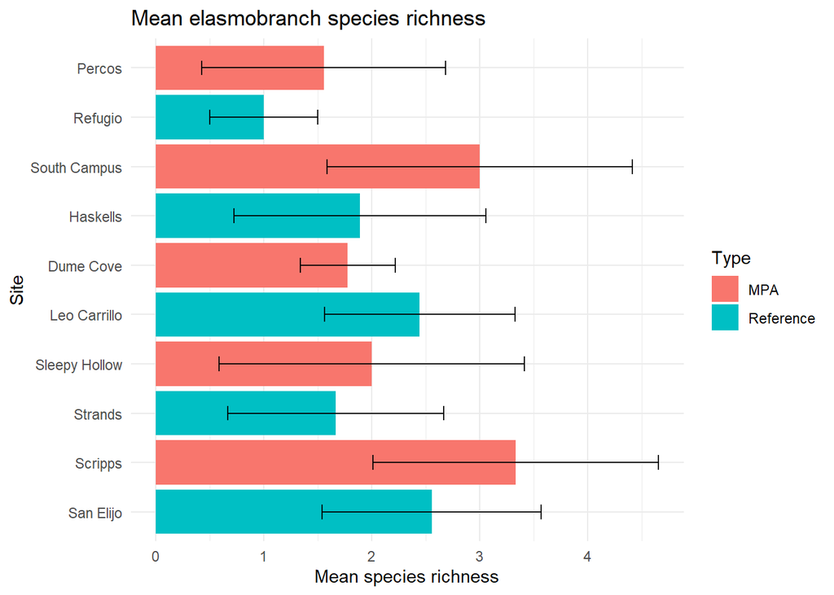

### MaxN

#### MaxN by species

MaxN statistic represents the maximum number of individuals belonging to each species counted in a single frame, across all sampling videos at each site (n = 9). Max % presence is the percentage of deployments in which a species is present, from the site in which the species had the highest % presence.

**Table 3.** MaxN statistic for each species present at the 10 sampling locations and Max % presence at any one location.

| Common name | Family | Max % presence | Percos | Refugio | South Campus | Haskells | Dume Cove | Leo Carrillo | Sleepy Hollow | Strands | Scripps | San Elijo |
| --- | --- | --- | --- | --- | --- | --- | --- | --- | --- | --- | --- | --- |
| Topsmelt | Atherinopsidae | 56 | 4 | 5 |  | 20 | 28 | 3 |  | 1 | 99 |  |
| Unknown Silverside | Atherinopsidae | 56 |  | 2 | 40 | 12 | 129 | 1 | 1 | 14 | 158 | 103 |
| Pacific jack mackerel | Carangidae | 11 |  |  |  | 3 |  |  |  |  |  |  |
| Diamond stingray | Dasyatidae | 22 |  |  |  |  |  |  |  |  | 1 |  |
| Black perch | Embiotocidae | 44 |  |  | 3 |  | 9 |  | 1 |  |  |  |
| Pile perch | Embiotocidae | 11 |  |  |  |  | 1 |  |  |  |  |  |
| Walleye surfperch | Embiotocidae | 33 | 145 | 10 | 2 |  | 26 | 17 |  |  |  | 4 |
| Barred surfperch | Embiotocidae | 67 | 46 | 2 | 3 | 8 |  | 5 |  |  |  |  |
| Calico surfperch | Embiotocidae | 11 | 2 |  |  |  |  |  |  |  |  |  |
| Shiner perch | Embiotocidae | 11 |  | 1 |  |  |  |  |  |  |  |  |
| Silver surfperch | Embiotocidae | 11 |  | 18 |  |  |  |  |  |  |  |  |
| Dwarf perch | Embiotocidae | 56 |  |  | 3 |  |  |  |  |  |  |  |
| Rainbow surfperch | Embiotocidae | 11 |  |  | 1 |  |  |  |  |  |  |  |
| Rubberlip seaperch | Embiotocidae | 11 |  |  | 1 |  |  |  |  |  |  |  |
| Sargo | Haemulidae | 56 |  |  | 1 |  | 2 |  | 1 |  | 1 | 1 |
| Horn shark | Heterodontidae | 22 |  |  | 1 |  |  | 1 |  |  |  |  |
| Halfmoon | Kyphosidae | 33 |  |  |  |  | 1 |  | 2 |  |  |  |
| Opaleye | Kyphosidae | 22 |  |  |  |  | 2 |  | 1 | 3 |  |  |
| Zebra perch | Kyphosidae | 56 |  |  |  |  | 32 |  | 1 | 6 |  |  |
| California sheephead | Labridae | 44 |  |  |  |  | 3 |  | 1 | 1 |  |  |
| Rock wrasse | Labridae | 22 |  |  | 1 |  | 1 |  | 2 |  |  | 1 |
| California moray | Muraenidae | 22 |  |  |  |  |  |  | 1 |  |  |  |
| Bat ray | Myliobatidae | 89 | 1 | 1 | 2 | 1 | 2 | 1 | 1 | 1 | 4 | 2 |
| Speckled sanddab | Paralichthyidae | 89 | 7 | 6 |  | 3 | 1 |  | 1 |  | 1 |  |
| California halibut | Paralichthyidae | 11 | 1 | 1 |  |  |  |  |  |  |  |  |
| Pacific sanddab | Paralichthyidae | 22 | 1 |  |  |  |  |  | 1 |  |  |  |
| Thornback guitarfish | Platyrhinidae | 56 | 2 | 2 | 2 | 1 | 1 | 1 | 1 |  | 1 | 1 |
| Shovelnose guitarfish | Rhinobatidae | 78 | 2 | 1 | 2 | 1 | 1 | 1 | 2 |  | 1 | 1 |
| Yellowfin croaker | Sciaenidae | 67 |  |  | 1 | 1 | 5 | 5 | 130 | 5 | 3 | 73 |
| California corbina | Sciaenidae | 44 | 5 |  |  | 1 |  | 1 | 2 | 1 | 2 | 2 |
| Queenfish | Sciaenidae | 11 |  |  |  |  |  |  | 92 |  |  | 60 |
| Spotfin croaker | Sciaenidae | 22 |  |  |  |  |  |  | 11 | 4 |  | 1 |
| Black croaker | Sciaenidae | 22 |  |  | 1 |  |  |  |  |  |  |  |
| White seabass | Sciaenidae | 11 |  |  |  |  |  |  |  | 1 |  |  |
| Kelp bass | Serranidae | 100 |  |  | 3 |  | 6 |  | 12 | 6 |  |  |
| Barred sand bass | Serranidae | 44 |  |  | 1 |  |  |  | 2 | 2 |  | 1 |
| Leopard shark | Triakidae | 100 | 1 |  | 7 | 1 | 2 | 2 | 1 | 4 | 1 | 1 |
| Grey smooth-hound | Triakidae | 11 |  |  |  |  |  |  |  |  |  | 1 |
| Round stingray | Urotrygonidae | 89 |  |  | 1 | 1 |  | 1 | 2 | 1 | 6 | 1 |

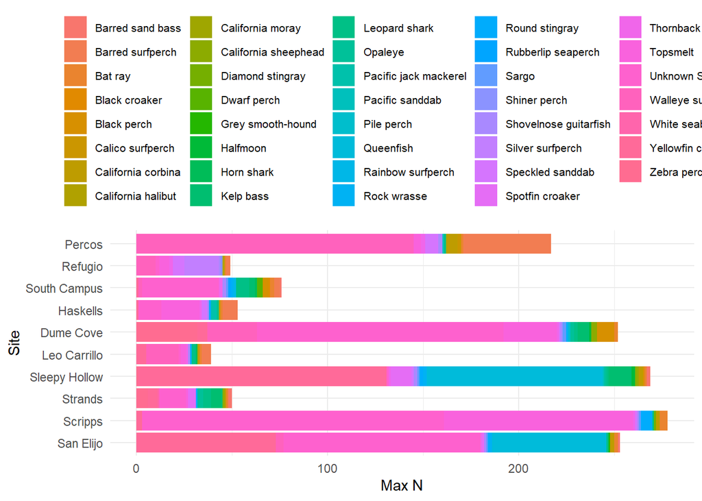

**Figure 3.** MaxN statistic for each site. Sites are ordered MPA first and reference second, with pairs in order of decreasing latitude. Stacked colors indicate unique species, with the exception of ‘unknown silversides’ possibly including topsmelt.

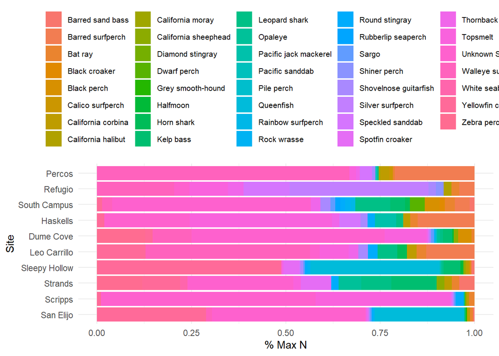

**Figure 4.** Composition of species at each site as a proportion of MaxN recorded. Sites are ordered MPA first and reference second, with pairs in order of decreasing latitude. Stacked colors indicate unique species, with the exception of ‘unknown silversides’ possibly including topsmelt.

#### Max N by family

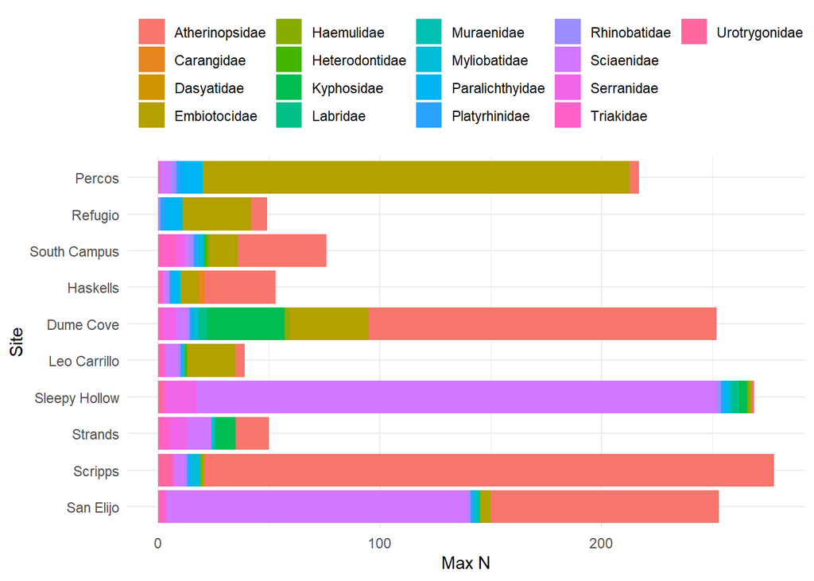

**Figure 5.** MaxN statistic aggregated by family for each site. Sites are ordered MPA first and reference second, with pairs in order of decreasing latitude. Stacked colors indicate unique families.

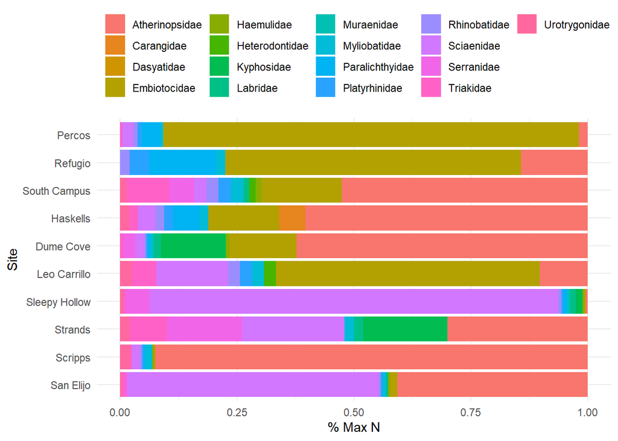

**Figure 6.** Composition of species aggregated by family at each site as a proportion of MaxN recorded. Percent contribution of MAxN is between 0 - 1.0. Sites are ordered MPA first and reference second, with pairs in order of decreasing latitude. Stacked colors indicate unique families.

### Mean maxN

**Table 3.** Summary statistics of average maxN of species at each site out of n deployments. This average includes maxN = 0 for deployments in which a species known to be present at the site is absent.

| Common name | Family | Percos Mean MaxN | Percos SD | Refugio Mean MaxN | Refugio SD | South Campus Mean MaxN | South Campus SD | Haskells Mean MaxN | Haskells SD | Dume Cove Mean MaxN | Dume Cove SD | Leo Carrillo Mean MaxN | Leo Carrillo SD | Sleepy Hollow Mean MaxN | Sleepy Hollow SD | Strands Mean MaxN | Strands SD | Scripps Mean MaxN | Scripps SD | San Elijo Mean MaxN | San Elijo SD |
| --- | --- | --- | --- | --- | --- | --- | --- | --- | --- | --- | --- | --- | --- | --- | --- | --- | --- | --- | --- | --- | --- |
| Topsmelt | Atherinopsidae | 1.00 | 1.58 | 2.00 | 2.35 |  |  | 4.33 | 6.71 | 3.11 | 9.33 | 0.67 | 1.32 |  |  | 0.11 | 0.33 | 11.00 | 33.00 |  |  |
| Unknown Silverside | Atherinopsidae |  |  | 0.89 | 0.93 | 4.56 | 13.30 | 1.67 | 3.94 | 23.00 | 43.43 | 0.44 | 0.53 | 0.11 | 0.33 | 2.00 | 4.69 | 26.78 | 51.21 | 19.00 | 34.89 |
| Pacific jack mackerel | Carangidae |  |  |  |  |  |  | 0.33 | 1.00 |  |  |  |  |  |  |  |  |  |  |  |  |
| Diamond stingray | Dasyatidae |  |  |  |  |  |  |  |  |  |  |  |  |  |  |  |  | 0.22 | 0.44 |  |  |
| Barred surfperch | Embiotocidae | 7.22 | 15.08 | 0.44 | 0.73 | 1.11 | 1.05 | 1.11 | 2.67 |  |  | 1.56 | 1.81 |  |  |  |  |  |  |  |  |
| Calico surfperch | Embiotocidae | 0.22 | 0.67 |  |  |  |  |  |  |  |  |  |  |  |  |  |  |  |  |  |  |
| Walleye surfperch | Embiotocidae | 16.11 | 48.33 | 1.22 | 3.31 | 0.44 | 0.73 |  |  | 4.22 | 9.08 | 2.00 | 5.63 |  |  |  |  |  |  | 0.44 | 1.33 |
| Shiner perch | Embiotocidae |  |  | 0.11 | 0.33 |  |  |  |  |  |  |  |  |  |  |  |  |  |  |  |  |
| Silver surfperch | Embiotocidae |  |  | 2.00 | 6.00 |  |  |  |  |  |  |  |  |  |  |  |  |  |  |  |  |
| Black perch | Embiotocidae |  |  |  |  | 0.89 | 1.17 |  |  | 1.33 | 3.04 |  |  | 0.11 | 0.33 |  |  |  |  |  |  |
| Dwarf perch | Embiotocidae |  |  |  |  | 0.78 | 0.97 |  |  |  |  |  |  |  |  |  |  |  |  |  |  |
| Rainbow surfperch | Embiotocidae |  |  |  |  | 0.11 | 0.33 |  |  |  |  |  |  |  |  |  |  |  |  |  |  |
| Rubberlip seaperch | Embiotocidae |  |  |  |  | 0.11 | 0.33 |  |  |  |  |  |  |  |  |  |  |  |  |  |  |
| Pile perch | Embiotocidae |  |  |  |  |  |  |  |  | 0.11 | 0.33 |  |  |  |  |  |  |  |  |  |  |
| Sargo | Haemulidae |  |  |  |  | 0.33 | 0.50 |  |  | 0.67 | 0.71 |  |  | 0.11 | 0.33 |  |  | 0.11 | 0.33 | 0.11 | 0.33 |
| Horn shark | Heterodontidae |  |  |  |  | 0.11 | 0.33 |  |  |  |  | 0.22 | 0.44 |  |  |  |  |  |  |  |  |
| Halfmoon | Kyphosidae |  |  |  |  |  |  |  |  | 0.33 | 0.50 |  |  | 0.22 | 0.67 |  |  |  |  |  |  |
| Opaleye | Kyphosidae |  |  |  |  |  |  |  |  | 0.22 | 0.67 |  |  | 0.11 | 0.33 | 0.44 | 1.01 |  |  |  |  |
| Zebra perch | Kyphosidae |  |  |  |  |  |  |  |  | 6.89 | 11.05 |  |  | 0.22 | 0.44 | 1.11 | 1.96 |  |  |  |  |
| Rock wrasse | Labridae |  |  |  |  | 0.11 | 0.33 |  |  | 0.11 | 0.33 |  |  | 0.33 | 0.71 |  |  |  |  | 0.11 | 0.33 |
| California sheephead | Labridae |  |  |  |  |  |  |  |  | 0.67 | 1.00 |  |  | 0.22 | 0.44 | 0.33 | 0.50 |  |  |  |  |
| California moray | Muraenidae |  |  |  |  |  |  |  |  |  |  |  |  | 0.22 | 0.44 |  |  |  |  |  |  |
| Bat ray | Myliobatidae | 0.33 | 0.50 | 0.11 | 0.33 | 0.67 | 0.87 | 0.56 | 0.53 | 0.78 | 0.67 | 0.56 | 0.53 | 0.33 | 0.50 | 0.33 | 0.50 | 1.89 | 1.27 | 0.67 | 0.71 |
| California halibut | Paralichthyidae | 0.11 | 0.33 | 0.11 | 0.33 |  |  |  |  |  |  |  |  |  |  |  |  |  |  |  |  |
| Pacific sanddab | Paralichthyidae | 0.11 | 0.33 |  |  |  |  |  |  |  |  |  |  | 0.22 | 0.44 |  |  |  |  |  |  |
| Speckled sanddab | Paralichthyidae | 3.78 | 2.44 | 1.78 | 1.72 |  |  | 0.56 | 1.13 | 0.11 | 0.33 |  |  | 0.11 | 0.33 |  |  | 0.11 | 0.33 |  |  |
| Thornback guitarfish | Platyrhinidae | 0.67 | 0.87 | 0.78 | 0.83 | 0.44 | 0.73 | 0.11 | 0.33 | 0.11 | 0.33 | 0.56 | 0.53 | 0.33 | 0.50 |  |  | 0.33 | 0.50 | 0.22 | 0.44 |
| Shovelnose guitarfish | Rhinobatidae | 0.78 | 0.83 | 0.33 | 0.50 | 1.00 | 0.71 | 0.33 | 0.50 | 0.22 | 0.44 | 0.22 | 0.44 | 0.44 | 0.73 |  |  | 0.56 | 0.53 | 0.44 | 0.53 |
| California corbina | Sciaenidae | 0.56 | 1.67 |  |  |  |  | 0.11 | 0.33 |  |  | 0.22 | 0.44 | 0.44 | 0.73 | 0.22 | 0.44 | 0.56 | 0.73 | 0.33 | 0.71 |
| Black croaker | Sciaenidae |  |  |  |  | 0.22 | 0.44 |  |  |  |  |  |  |  |  |  |  |  |  |  |  |
| Yellowfin croaker | Sciaenidae |  |  |  |  | 0.11 | 0.33 | 0.22 | 0.44 | 0.89 | 1.62 | 1.44 | 1.67 | 20.11 | 44.39 | 0.56 | 1.67 | 0.78 | 1.09 | 13.22 | 24.23 |
| Queenfish | Sciaenidae |  |  |  |  |  |  |  |  |  |  |  |  | 10.22 | 30.67 |  |  |  |  | 6.67 | 20.00 |
| Spotfin croaker | Sciaenidae |  |  |  |  |  |  |  |  |  |  |  |  | 1.67 | 3.74 | 0.56 | 1.33 |  |  | 0.22 | 0.44 |
| White seabass | Sciaenidae |  |  |  |  |  |  |  |  |  |  |  |  |  |  | 0.11 | 0.33 |  |  |  |  |
| Barred sand bass | Serranidae |  |  |  |  | 0.11 | 0.33 |  |  |  |  |  |  | 0.44 | 0.73 | 0.44 | 0.73 |  |  | 0.11 | 0.33 |
| Kelp bass | Serranidae |  |  |  |  | 1.22 | 0.83 |  |  | 2.44 | 1.81 |  |  | 3.89 | 4.86 | 1.78 | 2.11 |  |  |  |  |
| Leopard shark | Triakidae | 0.22 | 0.44 |  |  | 2.78 | 1.86 | 0.67 | 0.50 | 1.22 | 0.83 | 0.67 | 0.71 | 0.22 | 0.44 | 1.56 | 1.13 | 0.44 | 0.53 | 0.67 | 0.50 |
| Grey smooth-hound | Triakidae |  |  |  |  |  |  |  |  |  |  |  |  |  |  |  |  |  |  | 0.11 | 0.33 |
| Round stingray | Urotrygonidae |  |  |  |  | 0.33 | 0.50 | 0.22 | 0.44 |  |  | 0.33 | 0.50 | 0.89 | 0.60 | 0.44 | 0.53 | 2.44 | 1.74 | 0.56 | 0.53 |

**(a)**

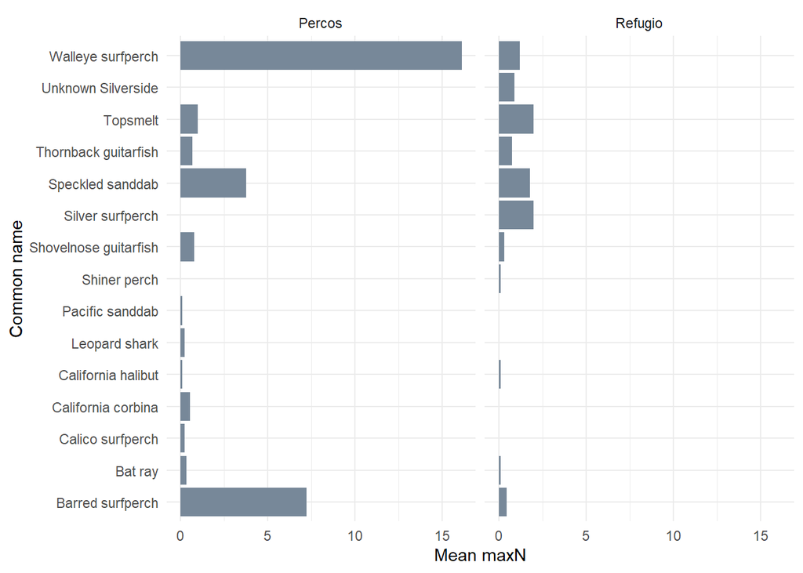

**(b)**

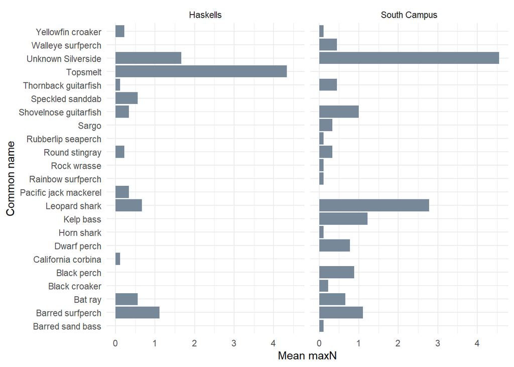

**(c)**

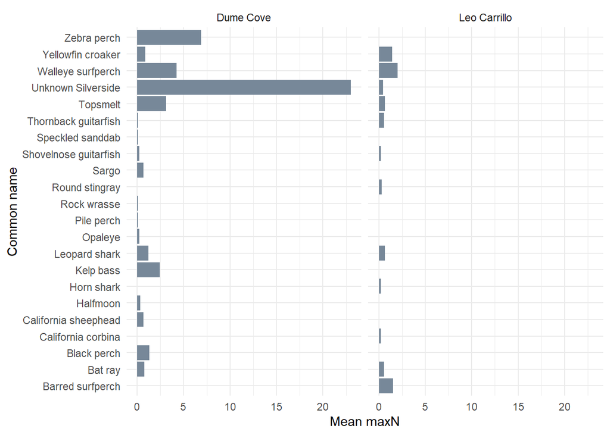

**(d)**

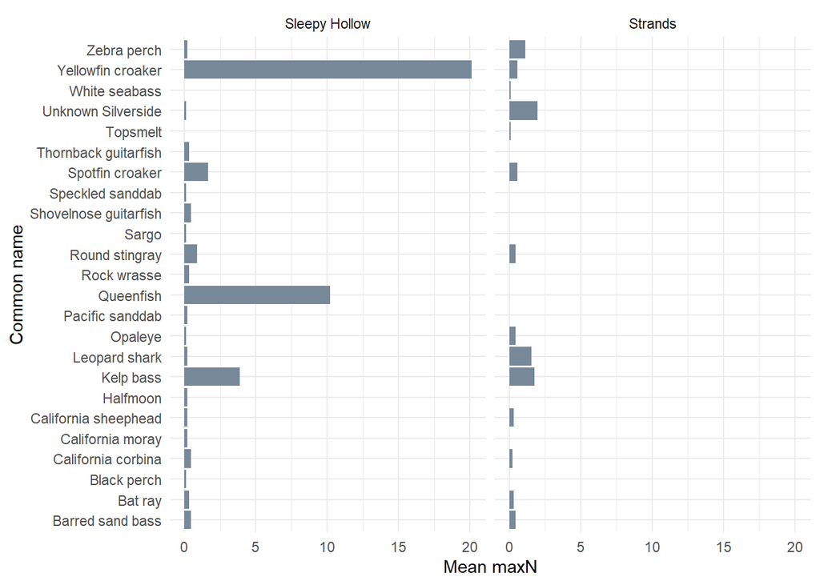

**(e)**

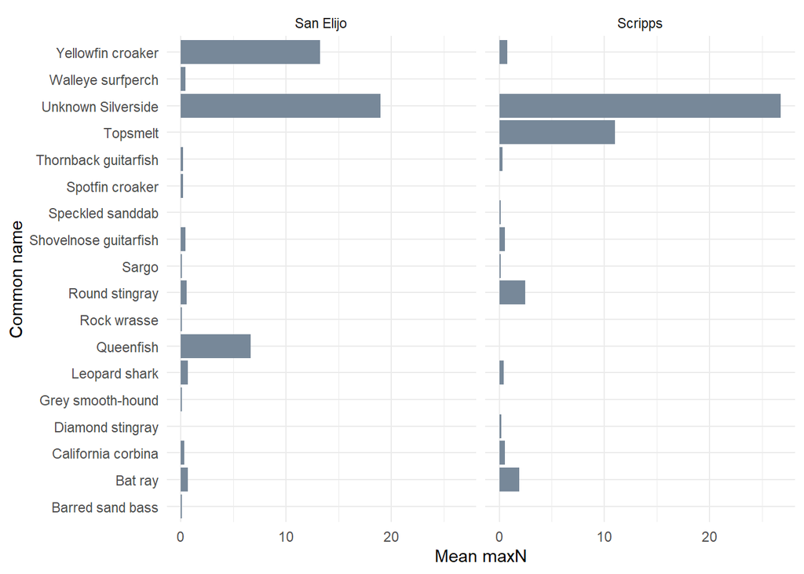

**Figure 7 (a-e).** Average MaxN of all species observed at each site for each site pair. Error bars were left off because of relatively large standard deviation (see Table 3).

Pull species list from maxN data